# Color schemes in accordance with the ICAE corporate design

Claudius Gräbner

2019-06-09

# Introduction

This package provides some functions that make it easy to create figures in accordance with the corporate design colors of the Institute for Comprehensive Analysis of the Economy (ICAE) at the Johannes Kepler University in Linz.[^1]

The package is still under development. Here is just a quick overview over its functions. Note that all exported function already have a complete documentation so you might refer to the help function for more details.

For the following porpuses, this example code and the packages `dplyr` as well as `ggplot2` are used:

```r
x <- seq(1,10, length.out=30)
y <- rep(1, length(x))
data <- data.frame(x=x, y=y)
palettes <- c("main", "cool", "hot", "mixed")
library(dplyr)
library(ggplot2)
library(icaeDesign)
```

# The palettes

Currently, the package contains the following four palettes:

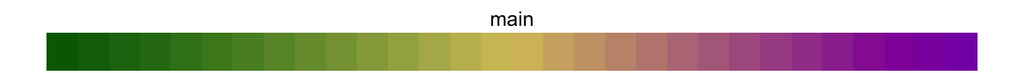

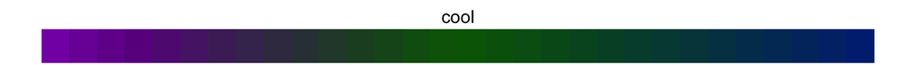

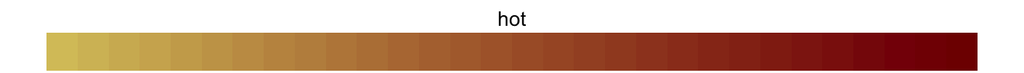

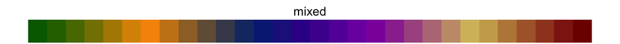

All of them come with both continuous and discrete versions.

## Using the palettes

### Create color vectors

To get a vector of arbitrary length that contains the hex codes for colors from the ICAE palettes introduced above, use the function `get_icae_colors`, which generates a vector of `n` different hex codes:

```r
list_of_cols <- list(
  "hot_colors" = get_icae_colors(n = 3, palette_used = "hot"),
  "cold_colors" = get_icae_colors(n = 2, palette_used = "cool",
                                  reverse_pal = TRUE),
  "mixed_colors" = get_icae_colors(4, palette_used = "mixed")
)
print(list_of_cols)
```

```
#> $hot_colors
#> [1] "#D8C469" "#AC6234" "#800000"
#>
#> $cold_colors
#> [1] "#002B80" "#8600B3"
#>
#> $mixed_colors
#> [1] "#006600" "#554F55" "#A1419A" "#800000"
```

You may also inquire the hex codes for the colors that are part of the corporate design:

```r
get_icae_colors(c("sand", "dark green"))
```

```
#>       sand dark green
#>  "#d8c469"  "#006600"
```

If you want to get the hex codes for all base colors of the corporate design call:

```r
get_icae_colors("all")
```

```
#>     orange     purple dark green       sand  dark blue   dark red
#>  "#ff9900"  "#8600b3"  "#006600"  "#d8c469"  "#002b80"  "#800000"
```

### Update ggplot2 objects

The key functions are `scale_color_icae()` and `scale_fill_icae()`, which allow to control the `color` and `fill` aesthetics in ggplot2 objects respectively.

In case of a barplot you might use `scale_fill_icae()` as follows:

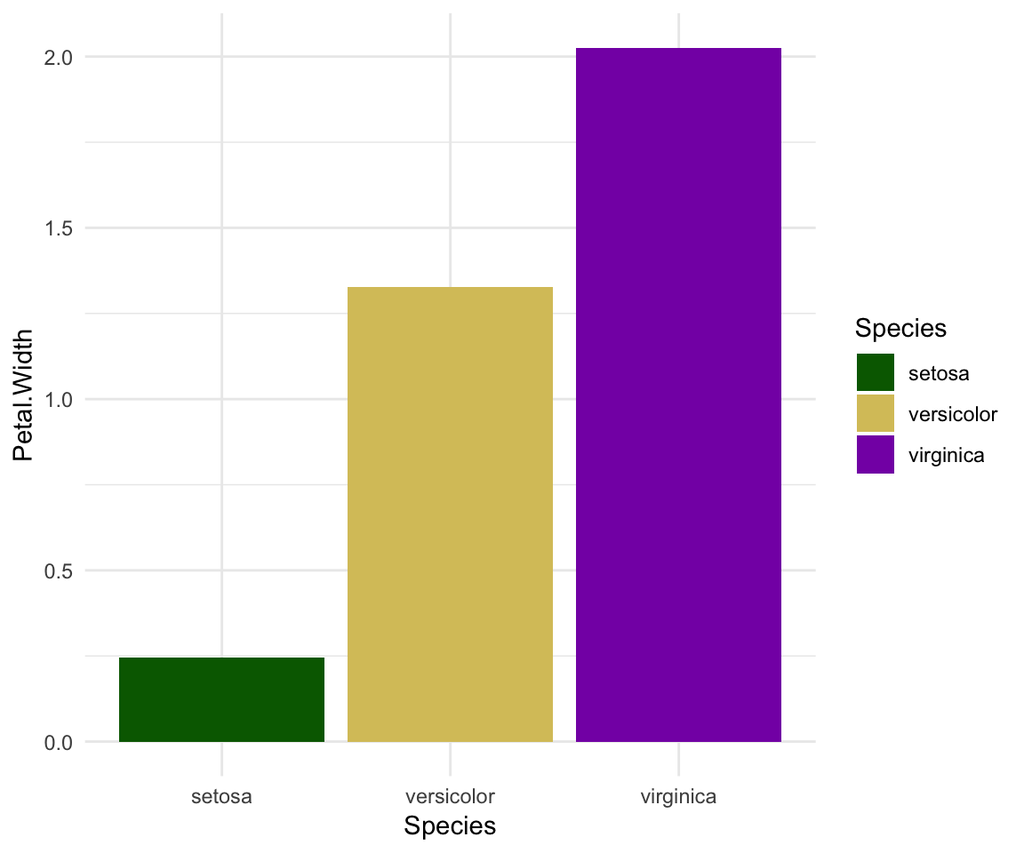

```r
data("iris")
iris %>%
  group_by(Species) %>%
  summarise_all(mean) %>%
  ungroup() %>%
  ggplot(.) +
  geom_bar(
    aes(x=Species, y=Petal.Width, fill=Species),
    stat = "identity"
    ) +
  scale_fill_icae() +
  theme_minimal()
```

Note that by default the functions return a discrete scale and for continuous cases you need to set `discrete = FALSE` explicitly.

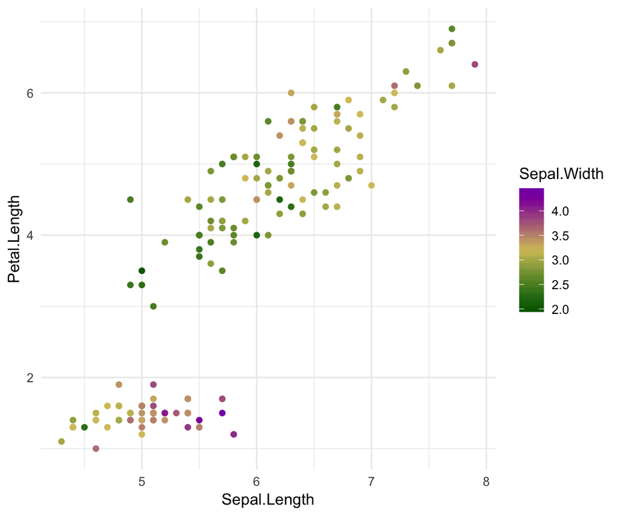

```r
iris %>%
  ggplot(.) + geom_point(
    aes(x=Sepal.Length, color=Sepal.Width, y=Petal.Length)
    ) +
  scale_color_icae(discrete = F) +
  theme_minimal()
```

For distinguishing discrete categories via color, such as countries, I found the `mixed` palette superior to `main`:

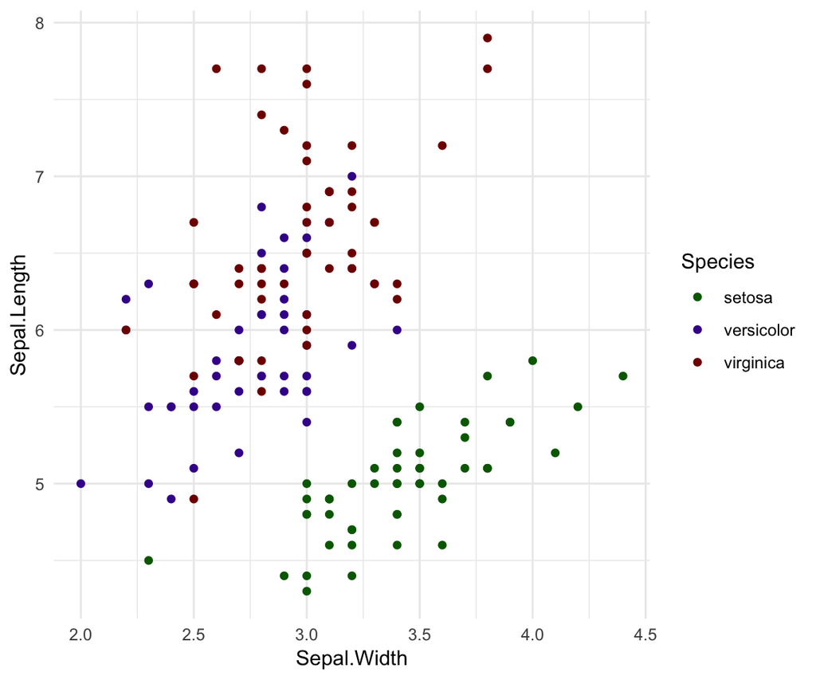

```r
iris %>%
  ggplot(.) + geom_point(
    aes(x=Sepal.Width, y=Sepal.Length, color=Species)
    ) +
  scale_color_icae(palette = "mixed", discrete = T) +
  theme_minimal()
```

# The new ggplot theme

The package also features a new theme for `ggplot2` objects, called `theme_icae`. It includes a number of changes that I found useful in improving plot appearance in general, but it is not specifically built to fit the ICAE color scheme.

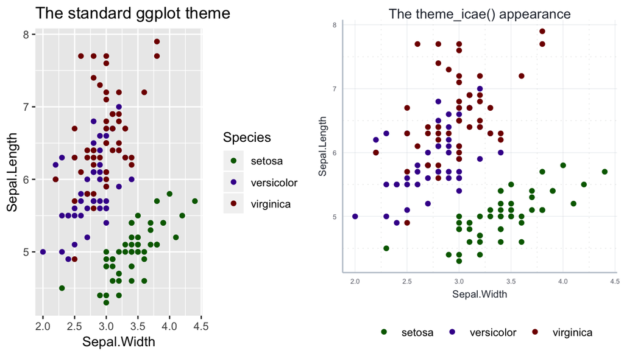

```r
classic_theme_plot <- iris %>%
  ggplot(.) + geom_point(
    aes(x=Sepal.Width, y=Sepal.Length, color=Species)
    ) +
  ggtitle("The standard ggplot theme") +
  scale_color_icae(palette = "mixed", discrete = T)

icae_theme_plot <- iris %>%
  ggplot(.) + geom_point(
    aes(x=Sepal.Width, y=Sepal.Length, color=Species)
    ) +
  ggtitle("The theme_icae() appearance") +
  scale_color_icae(palette = "mixed", discrete = T) +
  theme_icae()

ggpubr::ggarrange(classic_theme_plot, icae_theme_plot,
                  ncol = 2, nrow = 1, common.legend = F)
```

It also features acceptable defaults for non-standard specifications such as wrapped plots:

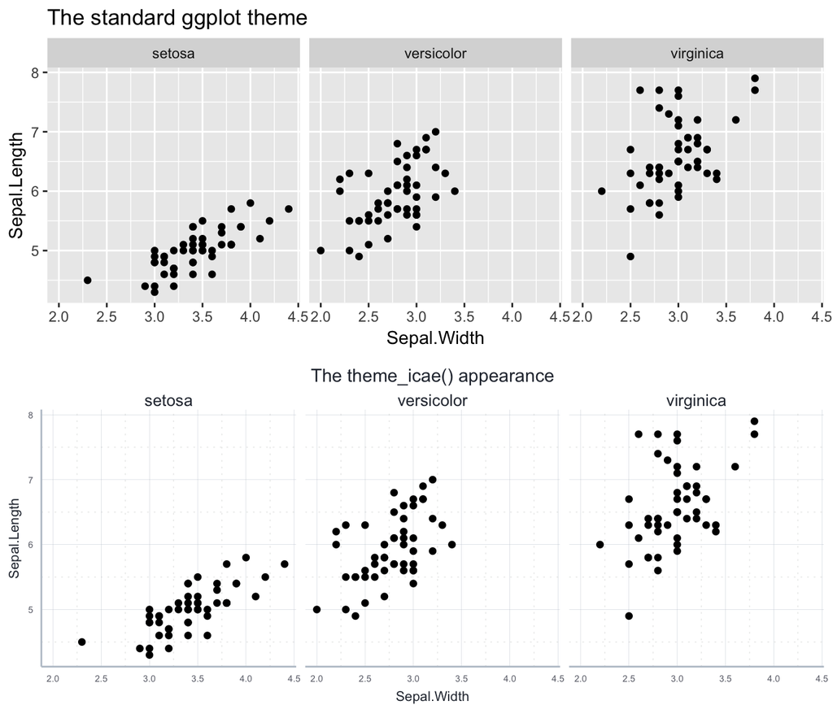

```r
classic_theme_plot <- iris %>%
  ggplot(.) + geom_point(
    aes(x=Sepal.Width, y=Sepal.Length)
    ) +
  ggtitle("The standard ggplot theme") +
  scale_color_icae(palette = "mixed", discrete = T) +
  facet_wrap(~Species)

icae_theme_plot <- iris %>%
  ggplot(.) + geom_point(
    aes(x=Sepal.Width, y=Sepal.Length)
    ) +
  ggtitle("The theme_icae() appearance") +
  scale_color_icae(palette = "mixed", discrete = T) +
  facet_wrap(~Species) +
  theme_icae()

ggpubr::ggarrange(classic_theme_plot, icae_theme_plot,
                  ncol = 1, nrow = 2, common.legend = F)
```

[^1]: More information about the ICAE can be found [here](https://www.jku.at/en/institute-for-comprehensive-analysis-of-the-economy/).